[GitHub](https://github.com/JuliaGeometry/DelaunayTriangulation.jl)[](https://github.com/JuliaGeometry/DelaunayTriangulation.jl/tree/main/docs/src/literate_tutorials/curve_bounded.jl)

# Triangulating Curve-Bounded Domains

In this tutorial, we show how we can triangulate a domain that is defined by curves rather than by straight lines. This tutorial makes use of functions introduced in the refinement tutorial.

Let us start by loading in the packages we will need.

```julia
using DelaunayTriangulation
using DelaunayTriangulation: EllipticalArc # CairoMakie also exports this
using CairoMakie
using StableRNGs
using LinearAlgebra
```

## Curves

In this package, only a small subset of curves are provided (although arbitrary curves could be provided by the user, as discussed in here. The curves, defined as parametric curves over a parameter $t ∈ [0, 1]$, are:

- `LineSegment`: Just a simple line segment between two points.
- `CircularArc`: A circular arc defined between two points and a center.
- `EllipticalArc`: An elliptical arc defined by two points, a center, a major radius, a minor radius, and an angle of rotation.
- `BezierCurve`: A Bézier curve defined by a set of control points.
- `BSpline`: A B-spline curve defined by a set of control points. Defaults to a cubic B-spline.
- `CatmullRomSpline`: A Catmull-Rom spline defined by a set of control points.

This set of curves is sufficient to represent a large number of curves.

## A Circular Domain

We start with a simple domain: a circle. In particular, we consider a circle of radius $r = 2$ centered at $(x, y) = (1/2, 2)$. In past tutorials, we would have defined a domain like this by a set of points around a boundary, e.g.:

```julia
n = 50
r = 2.0
xc, yc = 1 / 2, 2.0
θ = range(0, 2π, length=n + 1) |> collect;
θ[end] = θ[begin];
x = xc .+ r * cos.(θ)
y = yc .+ r * sin.(θ);
```

One problem with this approach is that we had to decide what value of $n$ to use for discretising this boundary. Instead, we can use `CircularArc`. For this, we use:

```julia
p = (xc + r, yc)
c = (xc, yc)
arc = CircularArc(p, p, c)
```

```
(::CircularArc) (generic function with 1 method)
```

Here, the syntax is `CircularArc(first_point, last_point, centre)`. Since the circle is closed, we use `p` for both `first_point` and `last_point`. Notice that the `arc` is a function. In particular,

```julia
typeof(arc) |> supertype |> supertype
```

```
Function
```

If we wanted to look at this circle, we would need to evaluate it at a set of $t \in [0, 1]$.

```julia
t = LinRange(0, 1, 2500)
points = arc.(t)
```

[output not shown]

[output not shown]

[output not shown]

[output not shown]

[output not shown]

[output not shown]

[output not shown]

[output not shown]

[output not shown]

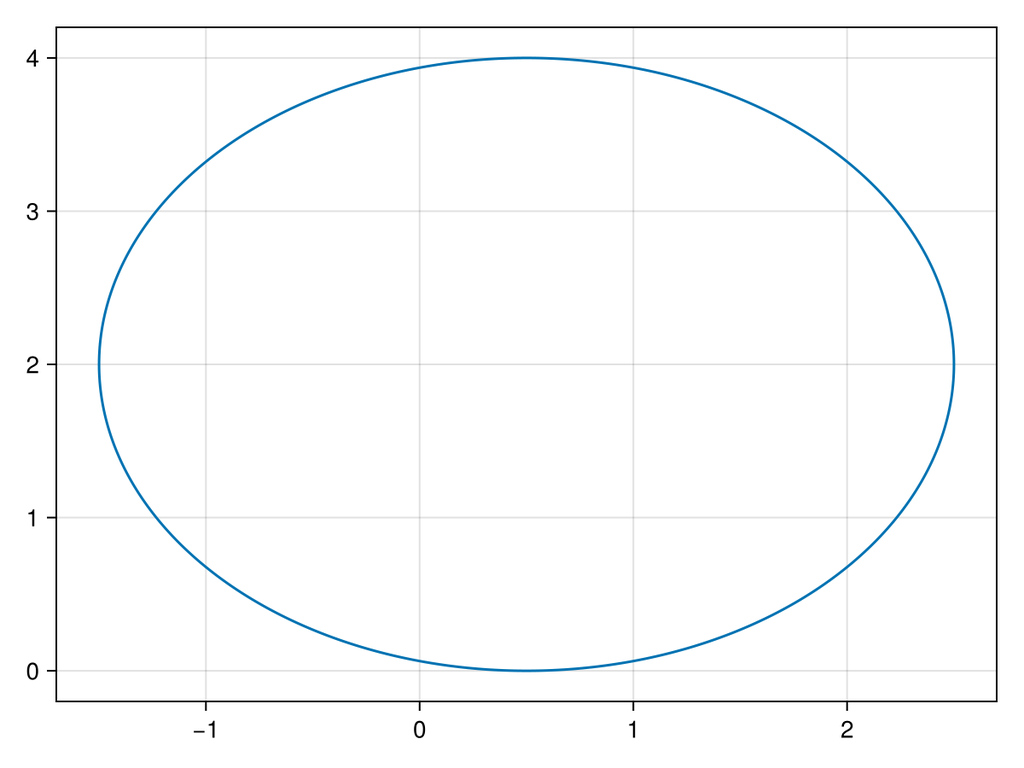

```julia
fig, ax, sc = lines(points)
```

Let's now triangulate this domain. We need to put the arc into its own vector, and we still need to pass a set of points into `triangulate`:

```julia
points = NTuple{2,Float64}[]
rng = StableRNG(123)
tri = triangulate(points; boundary_nodes=[arc], rng)
```

```
Delaunay Triangulation.
   Number of vertices: 8
   Number of triangles: 6
   Number of edges: 13
   Has boundary nodes: true
   Has ghost triangles: true
   Curve-bounded: true
   Weighted: false
   Constrained: true
```

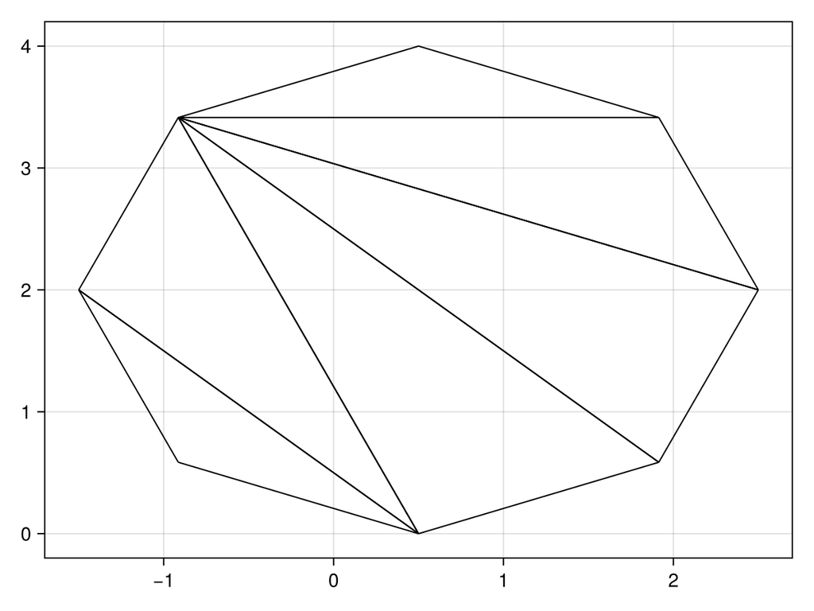

```julia
fig, ax, sc = triplot(tri)
fig
```

Notice that the domain doesn't look like a circle yet. This is because using `triangulate` on the curve just by itself isn't enough. In fact, the triangulation returned in this case is simply one where:

- No point is contained in the interior of any boundary edge's diametral circle.
- The total variation between any two neighbouring points is less than $\pi/2$, meaning that the absolute change in the angle along the parametric curve between these points is less than $\pi/2$.

This is probably not what we actually want, though. Instead, we need to refine the domain using mesh refinement. The syntax for this is the same as in the refinement tutorial:

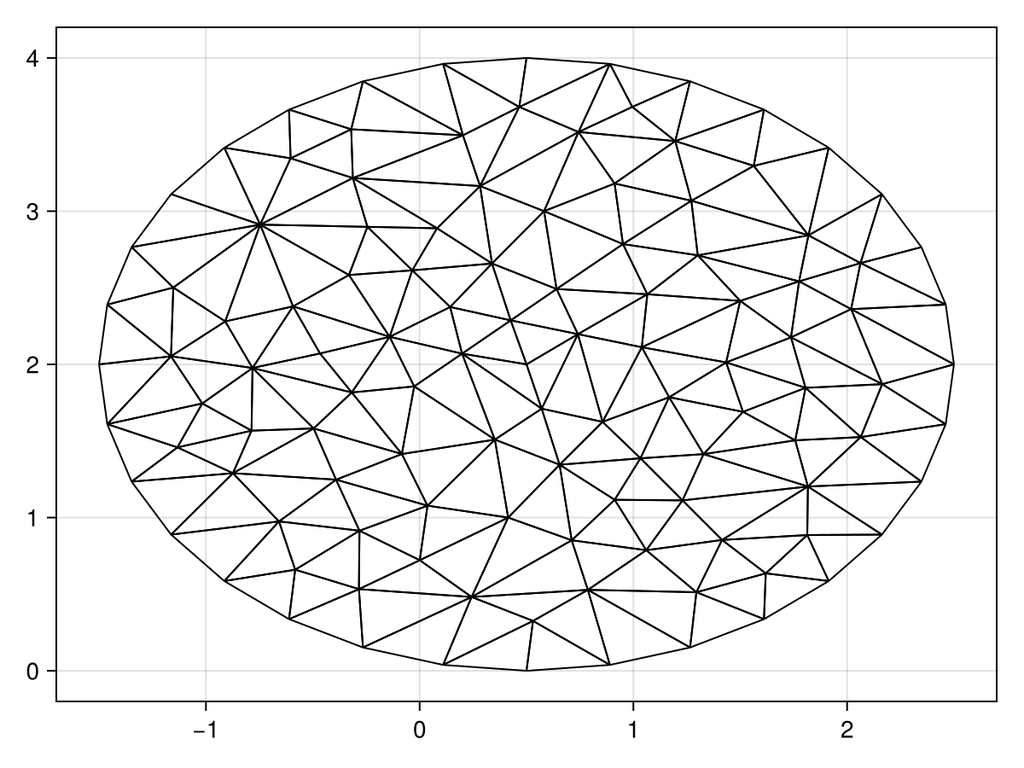

```julia
refine!(tri; max_area=1e-1, rng)
fig, ax, sc = triplot(tri)
fig
```

Much better! We have now triangulated our first curve-bounded domain.

## A Boundary Defined by Multiple Parametric Curves

We now take a domain which is defined by three separate curves: a circular arc, a B-spline, and a piecewise linear curve. For piecewise linear curves, we use the same method as we would in previous tutorials, where instead of using coordinates to define the boundary we use numbers that refer to points in the point set. To start, the point set we will be using is

```julia
points = [(0.1, 0.1), (0.15, 0.15), (0.23, 0.23), (0.009, 0.11), (0.0, -2.0), (0.2, -1.7), (0.000591, 0.00019), (0.111, -0.005), (-0.0001, -0.00991), (1.0, 0.0)]
```

```
10-element Vector{Tuple{Float64, Float64}}:
 (0.1, 0.1)
 (0.15, 0.15)
 (0.23, 0.23)
 (0.009, 0.11)
 (0.0, -2.0)
 (0.2, -1.7)
 (0.000591, 0.00019)
 (0.111, -0.005)
 (-0.0001, -0.00991)
 (1.0, 0.0)
```

Now, for the boundary, we will take:

- A circular arc defined between $(1, 0)$ and $(0, 1)$ centred at $(0, 0)$.
- A B-spline with control points $(0,1)$, $(-1, 2)$, $(-2,0)$, $(-2,-1)$, and $(0,-2)$.
- A piecewise linear curve defined between the fixth, sixth, and tenth points in `points`.

We can define these curves as follows:

```julia
arc = CircularArc((1.0, 0.0), (0.0, 1.0), (0.0, 0.0))
bspl = BSpline([(0.0, 1.0), (-1.0, 2.0), (-2.0, 0.0), (-2.0, -1.0), (0.0, -2.0)])
pce = [5, 6, 10]
```

```
3-element Vector{Int64}:
  5
  6
 10
```

Notice that we still must make sure that the curves connect, and that together the curves define a positively-oriented boundary. The domain we get from this looks like:

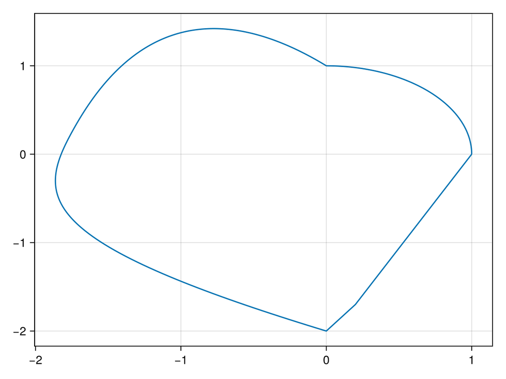

```julia
t = LinRange(0, 1, 1000)
pts = vcat(arc.(t), bspl.(t), points[pce])
fig, ax, sc = lines(pts)
fig
```

Let's now get a triangulation of this domain. We will use a custom constraint to force triangles closer to the origin to be smaller than those outside of it.

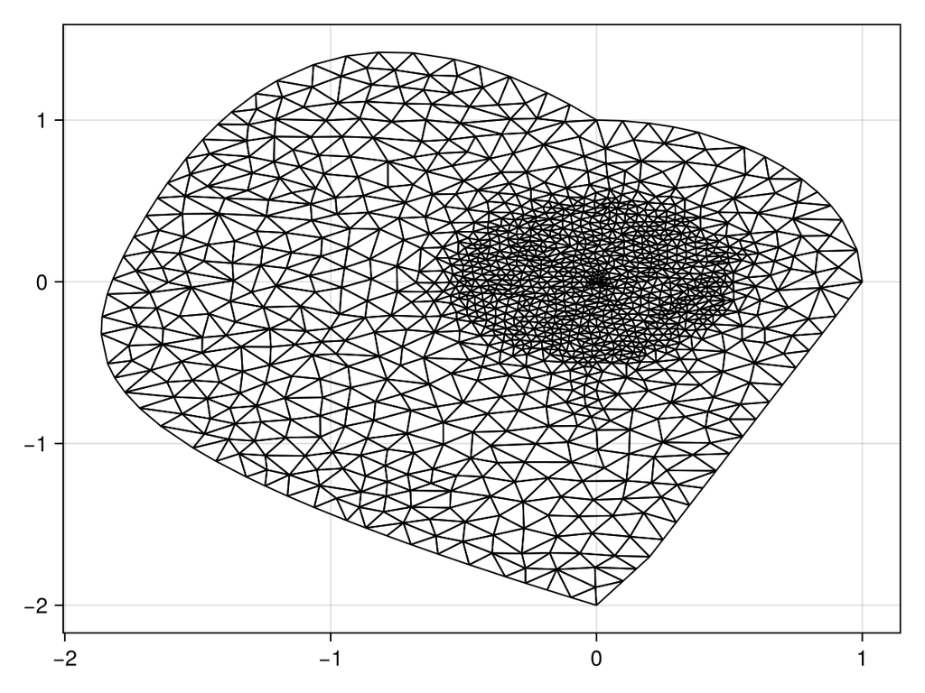

```julia
curve = [[arc], [bspl], pce]
rng = StableRNG(123)
tri = triangulate(points; boundary_nodes=curve, rng)
refine!(tri; max_area=1e-2, rng, custom_constraint=(_tri, T) -> begin
    i, j, k = triangle_vertices(T)
    p, q, r = get_point(_tri, i, j, k)
    c = (p .+ q .+ r) ./ 3
    return norm(c) < 1 / 2 && DelaunayTriangulation.triangle_area(p, q, r) > 1e-3
end)
fig, ax, sc = triplot(tri)
fig
```

## A Complicated Multiply-Connected Disjoint Domain

For our last example, we take a complicated case with a domain that is disjoint, and where the individual domains are multiply-connected. Let us give the domain followed by an explanation of how it is defined:

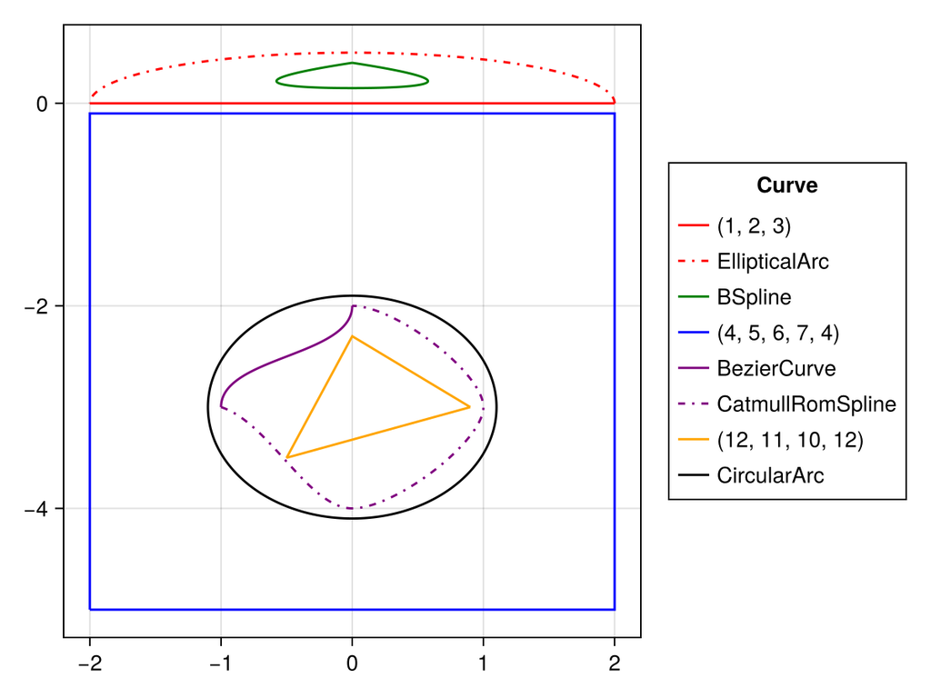

```julia
curve = [
    [
        [1, 2, 3], [EllipticalArc((2.0, 0.0), (-2.0, 0.0), (0.0, 0.0), 2, 1 / 2, 0.0)]
    ],
    [
        [BSpline([(0.0, 0.4), (1.0, 0.2), (0.0, 0.1), (-1.0, 0.2), (0.0, 0.4)])]
    ],
    [
        [4, 5, 6, 7, 4]
    ],
    [
        [BezierCurve([(0.0, -2.0), (0.0, -2.5), (-1.0, -2.5), (-1.0, -3.0)])], [CatmullRomSpline([(-1.0, -3.0), (0.0, -4.0), (1.0, -3.0), (0.0, -2.0)])]
    ],
    [
        [12, 11, 10, 12]
    ],
    [
        [CircularArc((1.1, -3.0), (1.1, -3.0), (0.0, -3.0), positive=false)]
    ]
]
points = [(-2.0, 0.0), (0.0, 0.0), (2.0, 0.0), (-2.0, -5.0), (2.0, -5.0), (2.0, -1 / 10), (-2.0, -1 / 10), (-1.0, -3.0), (0.0, -4.0), (0.0, -2.3), (-0.5, -3.5), (0.9, -3.0)]
t = LinRange(0, 1, 1000)
fig
fig = Figure()
ax = Axis(fig[1, 1])
lines!(ax, [get_point(points, curve[1][1]...)...], color=:red, label="(1, 2, 3)")
lines!(ax, curve[1][2][1].(t), color=:red, linestyle=:dashdot, label="EllipticalArc")
lines!(ax, curve[2][1][1].(t), color=:green, label="BSpline")
lines!(ax, [get_point(points, curve[3][1]...)...], color=:blue, label="(4, 5, 6, 7, 4)")
lines!(ax, curve[4][1][1].(t), color=:purple, label="BezierCurve")
lines!(ax, curve[4][2][1].(t), color=:purple, linestyle=:dashdot, label="CatmullRomSpline")
lines!(ax, [get_point(points, curve[5][1]...)...], color=:orange, label="(12, 11, 10, 12)")
lines!(ax, curve[6][1][1].(t), color=:black, label="CircularArc")
fig[1, 2] = Legend(fig, ax, "Curve")
fig
```

In addition to ensuring that the curves are all oriented correctly, care has also been taken in the definition of these curves to make sure that the curves connect at the correct points.

Let's now triangulate.

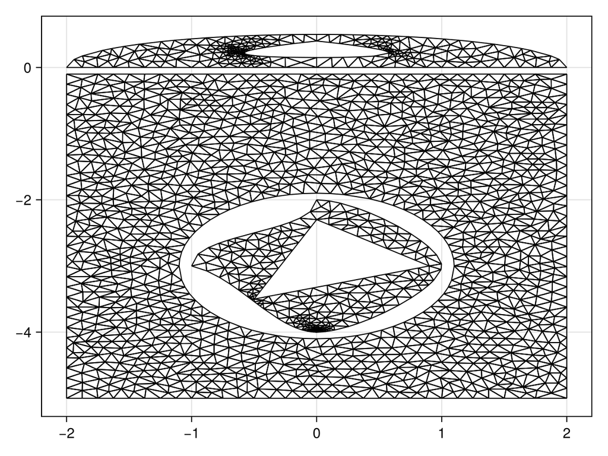

```julia
rng = StableRNG(123)
tri = triangulate(copy(points); boundary_nodes=curve, rng) # copying so that we don't mutate for the next section
refine!(tri; max_area=1e-2)
fig, ax, sc = triplot(tri)
fig
```

### Using Custom Constraints to Control Refinement

Let's give another example of using custom constraints to better control the refinement within different domains. Referencing the previous figure where we showed each domain by colour, let us try and use a coarse mesh in the region bounded between the red and green curves, a slightly denser mesh bounded between the blue and black curves, and finally a dense mesh in the region bounded between the purple and orange curves. To do this, we must have a method for deciding which region a given point resides in. This is what `find_polygon` for is, as we also use in the point-in-polygon tutorial. To write this function, we note that the indices of these polygons are 1, 3, and 4 for the red, blue, and purple regions, respectively.

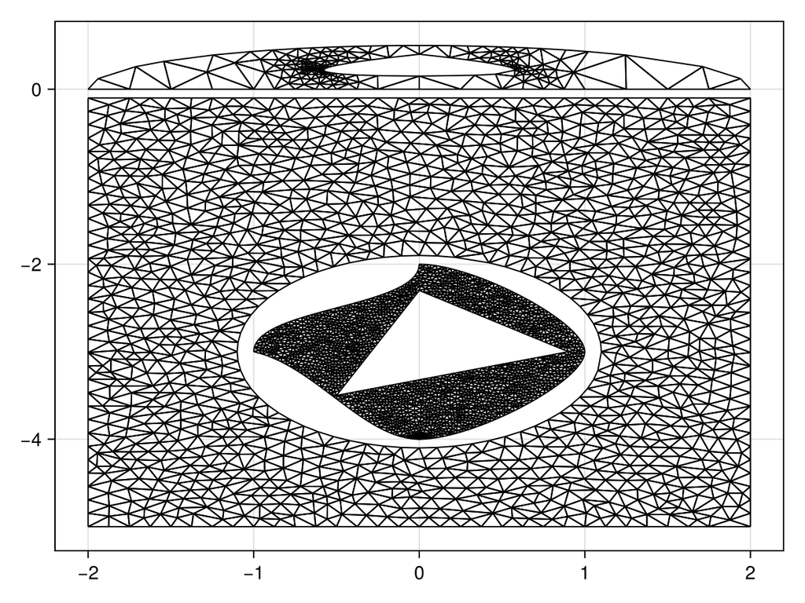

```julia
poly_constraint = (_tri, T) -> begin
    i, j, k = triangle_vertices(T)
    p, q, r = get_point(_tri, i, j, k)
    c = (p .+ q .+ r) ./ 3
    idx = find_polygon(_tri, c)
    if idx ∉ (1, 3, 4)
        return true
    end
    max_area = if idx == 1 # coarse
        1e-1
    elseif idx == 3 # medium
        1e-2
    else # dense
        1e-3
    end
    area = DelaunayTriangulation.triangle_area(p, q, r)
    return area > max_area
end
rng = StableRNG(123)
tri = triangulate(points; boundary_nodes=curve, rng)
refine!(tri; custom_constraint=poly_constraint, rng)
fig, ax, sc = triplot(tri)
fig
```

## Defining a New Parametric Curve

Let us now give an example where we define a domain by a parametric curve that is not provided natively by this package. For this example, we consider the astroid, where

\[\begin{aligned} x(t) = \cos^3(2\pi t), \\ y(t) = \sin^3(2\pi t). \end{aligned}\]

Let's now meet these requirements.

```julia
struct Astroid <: DelaunayTriangulation.AbstractParametricCurve
    lookup_table::Vector{NTuple{2,Float64}}
end
function (c::Astroid)(t)
    if t == 0.0 || t == 1.0
        return (1.0, 0.0)
    end
    x = cos(2π * t)^3
    y = sin(2π * t)^3
    return (x, y)
end
function DelaunayTriangulation.differentiate(c::Astroid, t)
    x = -6π * sin(2π * t) * cos(2π * t)^2
    y = 6π * sin(2π * t)^2 * cos(2π * t)
    return (x, y)
end
function DelaunayTriangulation.twice_differentiate(c::Astroid, t)
    x = -12π^2 * cos(2π * t) * (cos(2π * t)^2 - 2sin(2π * t)^2)
    y = -12π^2 * sin(2π * t) * (sin(2π * t)^2 - 2cos(2π * t)^2)
    return (x, y)
end
function DelaunayTriangulation.thrice_differentiate(c::Astroid, t)
    x = 24π^3 * sin(2π * t) * (7cos(2π * t)^2 - 2sin(2π * t)^2)
    y = 24π^3 * cos(2π * t) * (2cos(2π * t)^2 - 7sin(2π * t)^2)
    return (x, y)
end
```

Let's now define an astroid curve and triangulate it.

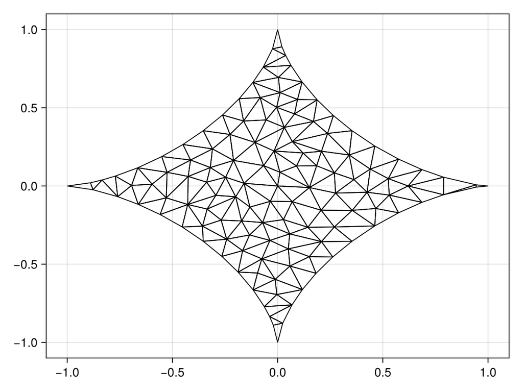

```julia
function Astroid(n::Int)
    lookup_table = Vector{NTuple{2,Float64}}(undef, n)
    c = Astroid(lookup_table)
    for i in 1:n
        lookup_table[i] = c((i - 1) / (n - 1))
    end
    return Astroid(lookup_table)
end
rng = StableRNG(123)
curve = Astroid(1000)
tri = triangulate(NTuple{2,Float64}[]; boundary_nodes=[curve], rng)
refine!(tri; max_area=1e-2)
fig, ax, sc = triplot(tri)
fig
```

## Just the code

An uncommented version of this example is given below. You can view the source code for this file [here](https://github.com/JuliaGeometry/DelaunayTriangulation.jl/tree/main/docs/src/literate_tutorials/curve_bounded.jl).

```julia
using DelaunayTriangulation
using DelaunayTriangulation: EllipticalArc # CairoMakie also exports this
using CairoMakie
using StableRNGs
using LinearAlgebra

n = 50
r = 2.0
xc, yc = 1 / 2, 2.0
θ = range(0, 2π, length=n + 1) |> collect;
θ[end] = θ[begin];
x = xc .+ r * cos.(θ)
y = yc .+ r * sin.(θ);

p = (xc + r, yc)
c = (xc, yc)
arc = CircularArc(p, p, c)

typeof(arc) |> supertype |> supertype

t = LinRange(0, 1, 2500)
points = arc.(t)

fig, ax, sc = lines(points)

points = NTuple{2,Float64}[]
rng = StableRNG(123)
tri = triangulate(points; boundary_nodes=[arc], rng)

fig, ax, sc = triplot(tri)
fig

refine!(tri; max_area=1e-1, rng)
fig, ax, sc = triplot(tri)
fig

points = [(0.1, 0.1), (0.15, 0.15), (0.23, 0.23), (0.009, 0.11), (0.0, -2.0), (0.2, -1.7), (0.000591, 0.00019), (0.111, -0.005), (-0.0001, -0.00991), (1.0, 0.0)]

arc = CircularArc((1.0, 0.0), (0.0, 1.0), (0.0, 0.0))
bspl = BSpline([(0.0, 1.0), (-1.0, 2.0), (-2.0, 0.0), (-2.0, -1.0), (0.0, -2.0)])
pce = [5, 6, 10]

t = LinRange(0, 1, 1000)
pts = vcat(arc.(t), bspl.(t), points[pce])
fig, ax, sc = lines(pts)
fig

curve = [[arc], [bspl], pce]
rng = StableRNG(123)
tri = triangulate(points; boundary_nodes=curve, rng)
refine!(tri; max_area=1e-2, rng, custom_constraint=(_tri, T) -> begin
    i, j, k = triangle_vertices(T)
    p, q, r = get_point(_tri, i, j, k)
    c = (p .+ q .+ r) ./ 3
    return norm(c) < 1 / 2 && DelaunayTriangulation.triangle_area(p, q, r) > 1e-3
end)
fig, ax, sc = triplot(tri)
fig

curve = [
    [
        [1, 2, 3], [EllipticalArc((2.0, 0.0), (-2.0, 0.0), (0.0, 0.0), 2, 1 / 2, 0.0)]
    ],
    [
        [BSpline([(0.0, 0.4), (1.0, 0.2), (0.0, 0.1), (-1.0, 0.2), (0.0, 0.4)])]
    ],
    [
        [4, 5, 6, 7, 4]
    ],
    [
        [BezierCurve([(0.0, -2.0), (0.0, -2.5), (-1.0, -2.5), (-1.0, -3.0)])], [CatmullRomSpline([(-1.0, -3.0), (0.0, -4.0), (1.0, -3.0), (0.0, -2.0)])]
    ],
    [
        [12, 11, 10, 12]
    ],
    [
        [CircularArc((1.1, -3.0), (1.1, -3.0), (0.0, -3.0), positive=false)]
    ]
]
points = [(-2.0, 0.0), (0.0, 0.0), (2.0, 0.0), (-2.0, -5.0), (2.0, -5.0), (2.0, -1 / 10), (-2.0, -1 / 10), (-1.0, -3.0), (0.0, -4.0), (0.0, -2.3), (-0.5, -3.5), (0.9, -3.0)]
t = LinRange(0, 1, 1000)
fig
fig = Figure()
ax = Axis(fig[1, 1])
lines!(ax, [get_point(points, curve[1][1]...)...], color=:red, label="(1, 2, 3)")
lines!(ax, curve[1][2][1].(t), color=:red, linestyle=:dashdot, label="EllipticalArc")
lines!(ax, curve[2][1][1].(t), color=:green, label="BSpline")
lines!(ax, [get_point(points, curve[3][1]...)...], color=:blue, label="(4, 5, 6, 7, 4)")
lines!(ax, curve[4][1][1].(t), color=:purple, label="BezierCurve")
lines!(ax, curve[4][2][1].(t), color=:purple, linestyle=:dashdot, label="CatmullRomSpline")
lines!(ax, [get_point(points, curve[5][1]...)...], color=:orange, label="(12, 11, 10, 12)")
lines!(ax, curve[6][1][1].(t), color=:black, label="CircularArc")
fig[1, 2] = Legend(fig, ax, "Curve")
fig

rng = StableRNG(123)
tri = triangulate(copy(points); boundary_nodes=curve, rng) # copying so that we don't mutate for the next section
refine!(tri; max_area=1e-2)
fig, ax, sc = triplot(tri)
fig

poly_constraint = (_tri, T) -> begin
    i, j, k = triangle_vertices(T)
    p, q, r = get_point(_tri, i, j, k)
    c = (p .+ q .+ r) ./ 3
    idx = find_polygon(_tri, c)
    if idx ∉ (1, 3, 4)
        return true
    end
    max_area = if idx == 1 # coarse
        1e-1
    elseif idx == 3 # medium
        1e-2
    else # dense
        1e-3
    end
    area = DelaunayTriangulation.triangle_area(p, q, r)
    return area > max_area
end
rng = StableRNG(123)
tri = triangulate(points; boundary_nodes=curve, rng)
refine!(tri; custom_constraint=poly_constraint, rng)
fig, ax, sc = triplot(tri)
fig

struct Astroid <: DelaunayTriangulation.AbstractParametricCurve
    lookup_table::Vector{NTuple{2,Float64}}
end
function (c::Astroid)(t)
    if t == 0.0 || t == 1.0
        return (1.0, 0.0)
    end
    x = cos(2π * t)^3
    y = sin(2π * t)^3
    return (x, y)
end
function DelaunayTriangulation.differentiate(c::Astroid, t)
    x = -6π * sin(2π * t) * cos(2π * t)^2
    y = 6π * sin(2π * t)^2 * cos(2π * t)
    return (x, y)
end
function DelaunayTriangulation.twice_differentiate(c::Astroid, t)
    x = -12π^2 * cos(2π * t) * (cos(2π * t)^2 - 2sin(2π * t)^2)
    y = -12π^2 * sin(2π * t) * (sin(2π * t)^2 - 2cos(2π * t)^2)
    return (x, y)
end
function DelaunayTriangulation.thrice_differentiate(c::Astroid, t)
    x = 24π^3 * sin(2π * t) * (7cos(2π * t)^2 - 2sin(2π * t)^2)
    y = 24π^3 * cos(2π * t) * (2cos(2π * t)^2 - 7sin(2π * t)^2)
    return (x, y)
end

function Astroid(n::Int)
    lookup_table = Vector{NTuple{2,Float64}}(undef, n)
    c = Astroid(lookup_table)
    for i in 1:n
        lookup_table[i] = c((i - 1) / (n - 1))
    end
    return Astroid(lookup_table)
end
rng = StableRNG(123)
curve = Astroid(1000)
tri = triangulate(NTuple{2,Float64}[]; boundary_nodes=[curve], rng)
refine!(tri; max_area=1e-2)
fig, ax, sc = triplot(tri)
fig
```

*This page was generated using Literate.jl.*